← Back to ML Fundamentals • Week 5 of 0–15

# Week 5 — ML Fundamentals

[Open in Colab](https://colab.research.google.com/github/sanketn26/learn-ml/blob/main/notebooks/week-05-saas.ipynb) [Open in VS Code](https://vscode.dev/github/sanketn26/learn-ml/blob/main/notebooks/week-05-saas.ipynb) Open in Jupyter [Download .ipynb](https://raw.githubusercontent.com/sanketn26/learn-ml/main/notebooks/week-05-saas.ipynb)

### 📝 How to Run This Notebook Locally

**1. Clone the repository:**  
`git clone https://github.com/sanketn26/learn-ml.git && cd learn-ml`

**2. Set up environment:**  
`python3 -m venv venv && source venv/bin/activate`  
`pip install jupyter notebook`

**3. Install course dependencies:**  
`pip install numpy pandas scikit-learn matplotlib scipy seaborn`  
`pip install torch`

**4. Open the notebook:**  
`jupyter notebook notebooks/week-05-saas.ipynb`

# Week 5 — Features Are the Model’s API

**Course:** Applied ML Foundations for SaaS Analytics  
**Who this is for:** Engineers who have designed request payloads. Feature engineering is that, plus a timeline rule.

## 🎯 What you will be able to do

- Treat a feature vector as a **versioned contract** the training job and the `/predict` handler must share
- Scale numbers so “dollars” and “click counts” can sit in the same model
- One-hot encode `plan_type` without treating free < starter < pro as a number line
- **Fit the scaler on train only** — the leak that will follow you to production
- Draw a wall between “known at score time” and “the future”

**Think of it like… an API contract + a time machine rule.**

The model only sees the JSON you send it. If a field would not exist when you score a live user at noon on Tuesday, it cannot exist in training either. That is leakage: the model cheated on the exam by reading tomorrow’s answer key.

**Laptop budget**

No GPU. Aimed at ~8 GB RAM. Training uses a few thousand sampled customers (or short sequences) so this notebook should finish in a **few minutes on CPU**. The ideas are the same if you later set `n=None` and train on all 50k rows.

```python
%matplotlib inline
from pathlib import Path
import sys

import numpy as np
import pandas as pd
import matplotlib.pyplot as plt

# Make the shared style kit importable whether you launch from notebooks/ or repo root
for _p in [Path.cwd(), Path.cwd() / "notebooks", Path.cwd().parent]:
    if (_p / "course_style.py").exists():
        sys.path.insert(0, str(_p))
        break

from course_style import apply_style, setup_plots, find_data_dir

apply_style()
setup_plots()
DATA = find_data_dir()
print(f"Data folder: {DATA}")
print("Laptop mode: no GPU required. Models use a sample so each week finishes in a few minutes on CPU.")

from sklearn.model_selection import train_test_split
from sklearn.preprocessing import StandardScaler, OneHotEncoder
from sklearn.compose import ColumnTransformer
from sklearn.pipeline import Pipeline
```

```
Data folder: /Users/sanketnaik/workspace/learn-ml/data
Laptop mode: no GPU required. Models use a sample so each week finishes in a few minutes on CPU.
```

## 🏢 Scenario — churn features the scoring service can actually compute

We want to flag accounts that will cancel. At score time we know:

- plan, MRR, tenure so far, usage so far, events so far

We do **not** know `churn_date`. We must not sneak it in as `has_churn_flag`.

```
 timeline:  signup -------- now -------- churn?
                       ▲
                       └── score time. Nothing to the right of this wall
                           may enter X. The label y may look right of the wall.
```

**Engineer mental model**

Features = request body. Scaler + encoder = middleware that *must ship next to the .pkl*. If production sends raw dollars and the model expects “standard deviations from the training mean,” every score is garbage and nobody gets a stack trace.

```python
from course_style import load_customer_360

df = load_customer_360(DATA)
print(df.shape)
print(df[["user_id", "plan_type", "mrr", "tenure_days", "total_usage",
          "features_adopted", "total_events", "is_churned"]].head())
print("\nLabel rate (churned):", df["is_churned"].mean().round(3))
```

```
(8000, 16)
       user_id plan_type     mrr  tenure_days  total_usage  features_adopted  \
0  user_049544       pro  102.69          530          4.0               2.0
1  user_015269      free    0.00           22          3.0               1.0
2  user_019235      free    0.00          468         10.0               2.0
3  user_039586      free    0.00          531          8.0               2.0
4  user_020468   starter   28.55           41          8.0               2.0

   total_events  is_churned
0           3.0           0
1           6.0           1
2           4.0           0
3           8.0           0
4           2.0           0

Label rate (churned): 0.065
```

## Scaling — why trees shrug and linear models panic

A tree only asks “is usage > 40?” — units do not matter.

**Math, translated**

`StandardScaler`: subtract the column’s mean, divide by its standard deviation. After that, “1” means “one typical-spread above average,” the same z-score idea from Week 1. `log1p(usage)` is “compress the whales so they do not own the axis.”

```
findfont: Failed to find font weight semibold, now using 700.
```

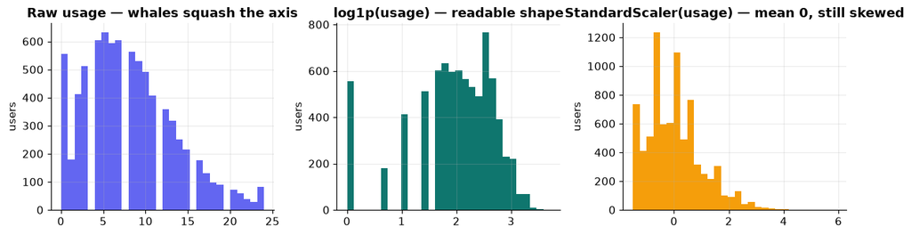

```
Trees: raw is fine.  Linear / k-means / nets: log then scale, and fit on TRAIN only.
```

```python
fig, axes = plt.subplots(1, 3, figsize=(12, 3.4))
axes[0].hist(df["total_usage"].clip(upper=np.percentile(df["total_usage"], 99)),
             bins=30, color="#6366f1")
axes[0].set_title("Raw usage — whales squash the axis")

axes[1].hist(df["log_usage"], bins=30, color="#0f766e")
axes[1].set_title("log1p(usage) — readable shape")

# WRONG: scaler fit on everyone. We show it only to picture the shape.
demo = StandardScaler().fit_transform(df[["total_usage"]])
axes[2].hist(demo, bins=30, color="#f59e0b")
axes[2].set_title("StandardScaler(usage) — mean 0, still skewed")
for ax in axes:
    ax.set_ylabel("users")
plt.tight_layout()
plt.show()

print("Trees: raw is fine.  Linear / k-means / nets: log then scale, and fit on TRAIN only.")
```

## Categories are not numbers

`plan_type` is free / starter / pro / enterprise. If you map those to 0,1,2,3 you are telling the model “enterprise is three more than free” and “the step from free→starter equals starter→pro.” Sometimes that is true. Usually it is a lie.

**One-hot:** four yes/no columns. Honest, a bit wide.

**Watch out — the scaler leak**

`scaler.fit_transform(X)` on the *full* table peeks at the test set’s mean and spread. That is a small leak that becomes a habit. Fit on train. Transform test. In production, the saved scaler *is* the fit.

```python
numeric = ["mrr", "tenure_days", "log_usage", "features_adopted",
           "total_events", "n_devices", "n_support"]
categorical = ["plan_type"]
label = "is_churned"

X = df[numeric + categorical]
y = df[label]

X_train, X_test, y_train, y_test = train_test_split(
    X, y, test_size=0.2, random_state=42, stratify=y
)

# Time-based split is even better (Week 12). Stratified random is the honest starter.

prep = ColumnTransformer(
    transformers=[
        ("num", StandardScaler(), numeric),
        ("cat", OneHotEncoder(handle_unknown="ignore"), categorical),
    ]
)
prep.fit(X_train)  # train only

X_train_t = prep.transform(X_train)
X_test_t = prep.transform(X_test)
names = numeric + list(prep.named_transformers_["cat"].get_feature_names_out(categorical))

print("Train rows", X_train_t.shape, "Test rows", X_test_t.shape)
print("Feature contract:")
for n in names:
    print(" ", n)

print("\nScaled train means (numeric should sit near 0):")
print(np.round(X_train_t[:, : len(numeric)].mean(axis=0), 3))
```

```
Train rows (6400, 11) Test rows (1600, 11)
Feature contract:
  mrr
  tenure_days
  log_usage
  features_adopted
  total_events
  n_devices
  n_support
  plan_type_enterprise
  plan_type_free
  plan_type_pro
  plan_type_starter

Scaled train means (numeric should sit near 0):
[-0.  0.  0. -0.  0. -0. -0.]
```

## Leakage hall of shame (we will keep coming back)

| Looks clever | Why it is cheating |
| --- | --- |
| `has_churn_flag` as a feature | That **is** the label |
| `lifetime_value = mrr * tenure` as a target, `tenure` as a feature | The model multiplies two columns it was handed |
| Fit scaler / target-encoder on all rows | Test set leaked into preprocessing |
| Random split when the world is a time series | The model trains on “next month” and tests on “last month” |

**Ship / don’t ship**

A feature ships if a tired on-call engineer can compute it from *today’s* warehouses for a single `user_id` with no peek at the label table. If you cannot write that function, it is not a feature.

## ✍️ Exercises

**1. Honest vs leaked scaler.** Fit a scaler on all rows, then only on train. Print the two means used for `mrr`. How far apart are they? (On 50k rows, tiny — the habit is still wrong.)

**2. Missingness flag.** Add `has_usage = total_usage > 0`. Does churn differ? Would you keep the flag *and* the count?

**3. Contract test.** Write `assert_score_payload(payload: dict)` that checks required keys and types. This is more production-shaped than another transformer.

## 🤔 Reflection

1. Why is “churned in the next 30 days” a better label than “ever churned”?
2. A teammate one-hot encodes `user_id`. What happens?
3. Where does the scaler live in your repo — next to the model, or re-fit in the API process?

## 🔗 Next week

Classification: a model is a function `features → risk score`. We pick a threshold the sales team can staff.

← Previous Week Back to ML Fundamentals Next Week →